# Risk Factor Analysis

## Outcome Variable

**Outcome Variable:** y_rate_wtkg

## Predictor Variables

**Intervention Variable:** predfeed6

**Adjustment Set:**

- arm
- sex
- month
- brthmon
- W_mage
- meducyrs
- feducyrs
- hhwealth_quart
- hfoodsec
- W_mhtcm
- W_mwtkg
- W_mbmi
- vagbrth
- W_birthwt
- W_birthlen
- single
- W_nrooms
- impfloor
- impsan
- safeh20
- delta_W_mage
- delta_meducyrs
- delta_feducyrs
- delta_hhwealth_quart
- delta_hfoodsec
- delta_W_mhtcm
- delta_W_mwtkg
- delta_W_mbmi
- delta_vagbrth
- delta_W_birthwt
- delta_W_birthlen
- delta_single
- delta_W_nrooms
- delta_impfloor
- delta_impsan
- delta_safeh20

## Stratifying Variables

The analysis was stratified on these variable(s):

- agecat
- studyid
- country

## Data Summary

| agecat | studyid | country | predfeed6 | n_cell | n |
| --- | --- | --- | --- | --- | --- |
| 0-3 months | EE | PAKISTAN | 1 | 35 | 39 |
| 0-3 months | EE | PAKISTAN | 0 | 4 | 39 |
| 0-3 months | GMS-Nepal | NEPAL | 1 | 368 | 501 |
| 0-3 months | GMS-Nepal | NEPAL | 0 | 133 | 501 |
| 0-3 months | JiVitA-3 | BANGLADESH | 1 | 9439 | 12206 |
| 0-3 months | JiVitA-3 | BANGLADESH | 0 | 2767 | 12206 |
| 0-3 months | JiVitA-4 | BANGLADESH | 1 | 1506 | 1793 |
| 0-3 months | JiVitA-4 | BANGLADESH | 0 | 287 | 1793 |
| 0-3 months | MAL-ED | BANGLADESH | 1 | 84 | 230 |
| 0-3 months | MAL-ED | BANGLADESH | 0 | 146 | 230 |
| 0-3 months | MAL-ED | BRAZIL | 1 | 30 | 210 |
| 0-3 months | MAL-ED | BRAZIL | 0 | 180 | 210 |
| 0-3 months | MAL-ED | INDIA | 1 | 11 | 216 |
| 0-3 months | MAL-ED | INDIA | 0 | 205 | 216 |
| 0-3 months | MAL-ED | NEPAL | 1 | 11 | 219 |
| 0-3 months | MAL-ED | NEPAL | 0 | 208 | 219 |
| 0-3 months | MAL-ED | PERU | 1 | 92 | 270 |
| 0-3 months | MAL-ED | PERU | 0 | 178 | 270 |
| 0-3 months | MAL-ED | SOUTH AFRICA | 1 | 3 | 234 |
| 0-3 months | MAL-ED | SOUTH AFRICA | 0 | 231 | 234 |
| 0-3 months | MAL-ED | TANZANIA, UNITED REPUBLIC OF | 1 | 1 | 219 |
| 0-3 months | MAL-ED | TANZANIA, UNITED REPUBLIC OF | 0 | 218 | 219 |
| 3-6 months | EE | PAKISTAN | 1 | 33 | 37 |
| 3-6 months | EE | PAKISTAN | 0 | 4 | 37 |
| 3-6 months | GMS-Nepal | NEPAL | 1 | 339 | 464 |
| 3-6 months | GMS-Nepal | NEPAL | 0 | 125 | 464 |
| 3-6 months | JiVitA-3 | BANGLADESH | 1 | 5812 | 7576 |
| 3-6 months | JiVitA-3 | BANGLADESH | 0 | 1764 | 7576 |
| 3-6 months | JiVitA-4 | BANGLADESH | 1 | 1504 | 1775 |
| 3-6 months | JiVitA-4 | BANGLADESH | 0 | 271 | 1775 |

[output cut: 150 more lines]

The following strata were considered:

- agecat: 0-3 months, studyid: EE, country: PAKISTAN
- agecat: 0-3 months, studyid: GMS-Nepal, country: NEPAL
- agecat: 0-3 months, studyid: JiVitA-3, country: BANGLADESH
- agecat: 0-3 months, studyid: JiVitA-4, country: BANGLADESH
- agecat: 0-3 months, studyid: MAL-ED, country: BANGLADESH
- agecat: 0-3 months, studyid: MAL-ED, country: BRAZIL
- agecat: 0-3 months, studyid: MAL-ED, country: INDIA
- agecat: 0-3 months, studyid: MAL-ED, country: NEPAL
- agecat: 0-3 months, studyid: MAL-ED, country: PERU
- agecat: 0-3 months, studyid: MAL-ED, country: SOUTH AFRICA
- agecat: 0-3 months, studyid: MAL-ED, country: TANZANIA, UNITED REPUBLIC OF
- agecat: 12-15 months, studyid: EE, country: PAKISTAN
- agecat: 12-15 months, studyid: GMS-Nepal, country: NEPAL
- agecat: 12-15 months, studyid: JiVitA-4, country: BANGLADESH
- agecat: 12-15 months, studyid: LCNI-5, country: MALAWI
- agecat: 12-15 months, studyid: MAL-ED, country: BANGLADESH
- agecat: 12-15 months, studyid: MAL-ED, country: BRAZIL
- agecat: 12-15 months, studyid: MAL-ED, country: INDIA
- agecat: 12-15 months, studyid: MAL-ED, country: NEPAL
- agecat: 12-15 months, studyid: MAL-ED, country: PERU
- agecat: 12-15 months, studyid: MAL-ED, country: SOUTH AFRICA
- agecat: 12-15 months, studyid: MAL-ED, country: TANZANIA, UNITED REPUBLIC OF
- agecat: 12-15 months, studyid: SAS-FoodSuppl, country: INDIA
- agecat: 15-18 months, studyid: EE, country: PAKISTAN
- agecat: 15-18 months, studyid: GMS-Nepal, country: NEPAL
- agecat: 15-18 months, studyid: JiVitA-4, country: BANGLADESH
- agecat: 15-18 months, studyid: LCNI-5, country: MALAWI
- agecat: 15-18 months, studyid: MAL-ED, country: BANGLADESH
- agecat: 15-18 months, studyid: MAL-ED, country: BRAZIL
- agecat: 15-18 months, studyid: MAL-ED, country: INDIA
- agecat: 15-18 months, studyid: MAL-ED, country: NEPAL
- agecat: 15-18 months, studyid: MAL-ED, country: PERU
- agecat: 15-18 months, studyid: MAL-ED, country: SOUTH AFRICA
- agecat: 15-18 months, studyid: MAL-ED, country: TANZANIA, UNITED REPUBLIC OF
- agecat: 15-18 months, studyid: SAS-FoodSuppl, country: INDIA
- agecat: 18-21 months, studyid: EE, country: PAKISTAN
- agecat: 18-21 months, studyid: GMS-Nepal, country: NEPAL
- agecat: 18-21 months, studyid: LCNI-5, country: MALAWI
- agecat: 18-21 months, studyid: MAL-ED, country: BANGLADESH
- agecat: 18-21 months, studyid: MAL-ED, country: BRAZIL
- agecat: 18-21 months, studyid: MAL-ED, country: INDIA
- agecat: 18-21 months, studyid: MAL-ED, country: NEPAL
- agecat: 18-21 months, studyid: MAL-ED, country: PERU
- agecat: 18-21 months, studyid: MAL-ED, country: SOUTH AFRICA
- agecat: 18-21 months, studyid: MAL-ED, country: TANZANIA, UNITED REPUBLIC OF
- agecat: 21-24 months, studyid: EE, country: PAKISTAN
- agecat: 21-24 months, studyid: GMS-Nepal, country: NEPAL
- agecat: 21-24 months, studyid: LCNI-5, country: MALAWI
- agecat: 21-24 months, studyid: MAL-ED, country: BANGLADESH
- agecat: 21-24 months, studyid: MAL-ED, country: BRAZIL
- agecat: 21-24 months, studyid: MAL-ED, country: INDIA
- agecat: 21-24 months, studyid: MAL-ED, country: NEPAL
- agecat: 21-24 months, studyid: MAL-ED, country: PERU
- agecat: 21-24 months, studyid: MAL-ED, country: SOUTH AFRICA
- agecat: 21-24 months, studyid: MAL-ED, country: TANZANIA, UNITED REPUBLIC OF
- agecat: 3-6 months, studyid: EE, country: PAKISTAN
- agecat: 3-6 months, studyid: GMS-Nepal, country: NEPAL
- agecat: 3-6 months, studyid: JiVitA-3, country: BANGLADESH
- agecat: 3-6 months, studyid: JiVitA-4, country: BANGLADESH
- agecat: 3-6 months, studyid: MAL-ED, country: BANGLADESH
- agecat: 3-6 months, studyid: MAL-ED, country: BRAZIL
- agecat: 3-6 months, studyid: MAL-ED, country: INDIA
- agecat: 3-6 months, studyid: MAL-ED, country: NEPAL
- agecat: 3-6 months, studyid: MAL-ED, country: PERU
- agecat: 3-6 months, studyid: MAL-ED, country: SOUTH AFRICA
- agecat: 3-6 months, studyid: MAL-ED, country: TANZANIA, UNITED REPUBLIC OF
- agecat: 6-9 months, studyid: EE, country: PAKISTAN
- agecat: 6-9 months, studyid: GMS-Nepal, country: NEPAL
- agecat: 6-9 months, studyid: JiVitA-4, country: BANGLADESH
- agecat: 6-9 months, studyid: LCNI-5, country: MALAWI
- agecat: 6-9 months, studyid: MAL-ED, country: BANGLADESH
- agecat: 6-9 months, studyid: MAL-ED, country: BRAZIL
- agecat: 6-9 months, studyid: MAL-ED, country: INDIA
- agecat: 6-9 months, studyid: MAL-ED, country: NEPAL
- agecat: 6-9 months, studyid: MAL-ED, country: PERU
- agecat: 6-9 months, studyid: MAL-ED, country: SOUTH AFRICA
- agecat: 6-9 months, studyid: MAL-ED, country: TANZANIA, UNITED REPUBLIC OF
- agecat: 6-9 months, studyid: SAS-FoodSuppl, country: INDIA
- agecat: 9-12 months, studyid: EE, country: PAKISTAN
- agecat: 9-12 months, studyid: GMS-Nepal, country: NEPAL
- agecat: 9-12 months, studyid: JiVitA-4, country: BANGLADESH
- agecat: 9-12 months, studyid: LCNI-5, country: MALAWI
- agecat: 9-12 months, studyid: MAL-ED, country: BANGLADESH
- agecat: 9-12 months, studyid: MAL-ED, country: BRAZIL
- agecat: 9-12 months, studyid: MAL-ED, country: INDIA
- agecat: 9-12 months, studyid: MAL-ED, country: NEPAL
- agecat: 9-12 months, studyid: MAL-ED, country: PERU
- agecat: 9-12 months, studyid: MAL-ED, country: SOUTH AFRICA
- agecat: 9-12 months, studyid: MAL-ED, country: TANZANIA, UNITED REPUBLIC OF
- agecat: 9-12 months, studyid: SAS-FoodSuppl, country: INDIA

### Dropped Strata

Some strata were dropped due to rare outcomes:

- agecat: 0-3 months, studyid: EE, country: PAKISTAN
- agecat: 0-3 months, studyid: MAL-ED, country: SOUTH AFRICA
- agecat: 0-3 months, studyid: MAL-ED, country: TANZANIA, UNITED REPUBLIC OF
- agecat: 3-6 months, studyid: EE, country: PAKISTAN
- agecat: 3-6 months, studyid: MAL-ED, country: SOUTH AFRICA
- agecat: 3-6 months, studyid: MAL-ED, country: TANZANIA, UNITED REPUBLIC OF
- agecat: 6-9 months, studyid: MAL-ED, country: SOUTH AFRICA
- agecat: 6-9 months, studyid: MAL-ED, country: TANZANIA, UNITED REPUBLIC OF
- agecat: 6-9 months, studyid: SAS-FoodSuppl, country: INDIA
- agecat: 9-12 months, studyid: MAL-ED, country: SOUTH AFRICA
- agecat: 9-12 months, studyid: MAL-ED, country: TANZANIA, UNITED REPUBLIC OF
- agecat: 9-12 months, studyid: SAS-FoodSuppl, country: INDIA
- agecat: 12-15 months, studyid: LCNI-5, country: MALAWI
- agecat: 12-15 months, studyid: MAL-ED, country: SOUTH AFRICA
- agecat: 12-15 months, studyid: MAL-ED, country: TANZANIA, UNITED REPUBLIC OF
- agecat: 12-15 months, studyid: SAS-FoodSuppl, country: INDIA
- agecat: 15-18 months, studyid: LCNI-5, country: MALAWI
- agecat: 15-18 months, studyid: MAL-ED, country: SOUTH AFRICA
- agecat: 15-18 months, studyid: MAL-ED, country: TANZANIA, UNITED REPUBLIC OF
- agecat: 15-18 months, studyid: SAS-FoodSuppl, country: INDIA
- agecat: 18-21 months, studyid: MAL-ED, country: SOUTH AFRICA
- agecat: 18-21 months, studyid: MAL-ED, country: TANZANIA, UNITED REPUBLIC OF
- agecat: 21-24 months, studyid: EE, country: PAKISTAN
- agecat: 21-24 months, studyid: MAL-ED, country: SOUTH AFRICA
- agecat: 21-24 months, studyid: MAL-ED, country: TANZANIA, UNITED REPUBLIC OF

## Methods Detail

We’re interested in the causal parameters $E[Y_a]$ for all values of $a \in \mathcal{A}$. These parameters represent the mean outcome if, possibly contrary to fact, we intervened to set all units to have $A=a$. Under the randomization and positivity assumptions, these are identified by the statistical parameters $\psi_a=E_W[E_{Y|A,W}(Y|A=a,W)]$. In addition, we’re interested in the mean of $Y$, $E[Y]$ under no intervention (the observed mean). We will estimate these parameters by using SuperLearner to fit the relevant likelihood factors – $E_{Y|A,W}(Y|A=a,W)$ and $p(A=a|W)$, and then updating our likelihood fit using a joint TMLE.

For unadjusted analyses ($W=\{\}$), initial likelihoods were estimated using Lrnr_glm to estimate the simple $E(Y|A)$ and Lrnr_mean to estimate $p(A)$. For adjusted analyses, a small library containing Lrnr_glmnet, Lrnr_xgboost, and Lrnr_mean was used.

Having estimated these parameters, we will then use the delta method to estimate relative risks and attributable risks relative to a prespecified baseline level of $A$.

# Results Detail

## Results Plots

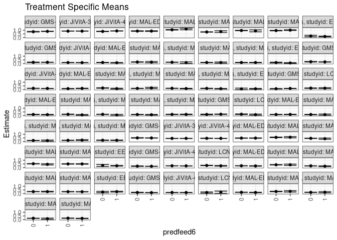

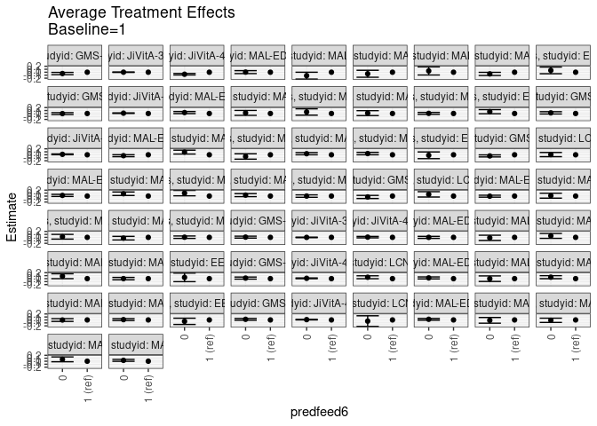

[figure not shown]

## Results Table

### Parameter: TSM

| agecat | studyid | country | intervention_level | baseline_level | estimate | ci_lower | ci_upper |
| --- | --- | --- | --- | --- | --- | --- | --- |
| 0-3 months | GMS-Nepal | NEPAL | 1 | NA | 0.8409797 | 0.8214595 | 0.8604999 |
| 0-3 months | GMS-Nepal | NEPAL | 0 | NA | 0.7962190 | 0.7619413 | 0.8304967 |
| 0-3 months | JiVitA-3 | BANGLADESH | 1 | NA | 0.8699447 | 0.8658648 | 0.8740245 |
| 0-3 months | JiVitA-3 | BANGLADESH | 0 | NA | 0.8707294 | 0.8636727 | 0.8777860 |
| 0-3 months | JiVitA-4 | BANGLADESH | 1 | NA | 0.9011904 | 0.8901390 | 0.9122417 |
| 0-3 months | JiVitA-4 | BANGLADESH | 0 | NA | 0.8332382 | 0.8088837 | 0.8575927 |
| 0-3 months | MAL-ED | BANGLADESH | 1 | NA | 0.8794034 | 0.8424142 | 0.9163925 |
| 0-3 months | MAL-ED | BANGLADESH | 0 | NA | 0.8830274 | 0.8512145 | 0.9148402 |
| 0-3 months | MAL-ED | BRAZIL | 1 | NA | 1.1734632 | 1.0640423 | 1.2828842 |
| 0-3 months | MAL-ED | BRAZIL | 0 | NA | 1.0570653 | 1.0209663 | 1.0931643 |
| 0-3 months | MAL-ED | INDIA | 1 | NA | 0.8112435 | 0.6966979 | 0.9257891 |
| 0-3 months | MAL-ED | INDIA | 0 | NA | 0.7587887 | 0.7349804 | 0.7825971 |
| 0-3 months | MAL-ED | NEPAL | 1 | NA | 0.9165963 | 0.7832674 | 1.0499252 |
| 0-3 months | MAL-ED | NEPAL | 0 | NA | 0.9594074 | 0.9312252 | 0.9875896 |
| 0-3 months | MAL-ED | PERU | 1 | NA | 1.0092280 | 0.9678594 | 1.0505966 |
| 0-3 months | MAL-ED | PERU | 0 | NA | 0.9525420 | 0.9201251 | 0.9849589 |
| 3-6 months | GMS-Nepal | NEPAL | 1 | NA | 0.4943147 | 0.4783696 | 0.5102598 |
| 3-6 months | GMS-Nepal | NEPAL | 0 | NA | 0.5024816 | 0.4741977 | 0.5307656 |
| 3-6 months | JiVitA-3 | BANGLADESH | 1 | NA | 0.4403957 | 0.4362035 | 0.4445879 |
| 3-6 months | JiVitA-3 | BANGLADESH | 0 | NA | 0.4391586 | 0.4308944 | 0.4474227 |
| 3-6 months | JiVitA-4 | BANGLADESH | 1 | NA | 0.4379795 | 0.4282827 | 0.4476763 |
| 3-6 months | JiVitA-4 | BANGLADESH | 0 | NA | 0.4455612 | 0.4234088 | 0.4677137 |
| 3-6 months | MAL-ED | BANGLADESH | 1 | NA | 0.4757600 | 0.4502960 | 0.5012240 |
| 3-6 months | MAL-ED | BANGLADESH | 0 | NA | 0.4753187 | 0.4529707 | 0.4976667 |
| 3-6 months | MAL-ED | BRAZIL | 1 | NA | 0.5903306 | 0.5091896 | 0.6714716 |
| 3-6 months | MAL-ED | BRAZIL | 0 | NA | 0.5741638 | 0.5401304 | 0.6081972 |
| 3-6 months | MAL-ED | INDIA | 1 | NA | 0.3948238 | 0.3142778 | 0.4753697 |
| 3-6 months | MAL-ED | INDIA | 0 | NA | 0.4438155 | 0.4252735 | 0.4623575 |
| 3-6 months | MAL-ED | NEPAL | 1 | NA | 0.4447126 | 0.3651998 | 0.5242254 |
| 3-6 months | MAL-ED | NEPAL | 0 | NA | 0.5264597 | 0.5052960 | 0.5476233 |

[output cut: 100 more lines]

### Parameter: E(Y)

| agecat | studyid | country | intervention_level | baseline_level | estimate | ci_lower | ci_upper |
| --- | --- | --- | --- | --- | --- | --- | --- |
| 0-3 months | GMS-Nepal | NEPAL | NA | NA | 0.8262343 | 0.8091204 | 0.8433482 |
| 0-3 months | JiVitA-3 | BANGLADESH | NA | NA | 0.8701010 | 0.8664010 | 0.8738010 |
| 0-3 months | JiVitA-4 | BANGLADESH | NA | NA | 0.8897715 | 0.8792902 | 0.9002529 |
| 0-3 months | MAL-ED | BANGLADESH | NA | NA | 0.8815161 | 0.8573098 | 0.9057224 |
| 0-3 months | MAL-ED | BRAZIL | NA | NA | 1.0702868 | 1.0355019 | 1.1050717 |
| 0-3 months | MAL-ED | INDIA | NA | NA | 0.7615268 | 0.7382819 | 0.7847718 |
| 0-3 months | MAL-ED | NEPAL | NA | NA | 0.9570869 | 0.9295107 | 0.9846631 |
| 0-3 months | MAL-ED | PERU | NA | NA | 0.9722590 | 0.9463823 | 0.9981357 |
| 3-6 months | GMS-Nepal | NEPAL | NA | NA | 0.4969184 | 0.4830319 | 0.5108048 |
| 3-6 months | JiVitA-3 | BANGLADESH | NA | NA | 0.4401107 | 0.4363074 | 0.4439140 |
| 3-6 months | JiVitA-4 | BANGLADESH | NA | NA | 0.4390246 | 0.4301757 | 0.4478736 |
| 3-6 months | MAL-ED | BANGLADESH | NA | NA | 0.4752798 | 0.4582021 | 0.4923576 |
| 3-6 months | MAL-ED | BRAZIL | NA | NA | 0.5781976 | 0.5469697 | 0.6094254 |
| 3-6 months | MAL-ED | INDIA | NA | NA | 0.4421852 | 0.4242493 | 0.4601211 |
| 3-6 months | MAL-ED | NEPAL | NA | NA | 0.5212498 | 0.5005373 | 0.5419623 |
| 3-6 months | MAL-ED | PERU | NA | NA | 0.4986791 | 0.4796733 | 0.5176848 |
| 6-9 months | EE | PAKISTAN | NA | NA | 0.2545881 | 0.2127069 | 0.2964693 |
| 6-9 months | GMS-Nepal | NEPAL | NA | NA | 0.1872663 | 0.1750716 | 0.1994611 |
| 6-9 months | JiVitA-4 | BANGLADESH | NA | NA | 0.2387113 | 0.2332818 | 0.2441408 |
| 6-9 months | LCNI-5 | MALAWI | NA | NA | 0.2829175 | 0.2578313 | 0.3080037 |
| 6-9 months | MAL-ED | BANGLADESH | NA | NA | 0.2415793 | 0.2267676 | 0.2563910 |
| 6-9 months | MAL-ED | BRAZIL | NA | NA | 0.3831499 | 0.3570859 | 0.4092138 |
| 6-9 months | MAL-ED | INDIA | NA | NA | 0.2373787 | 0.2225426 | 0.2522148 |
| 6-9 months | MAL-ED | NEPAL | NA | NA | 0.2701634 | 0.2553060 | 0.2850207 |
| 6-9 months | MAL-ED | PERU | NA | NA | 0.2613933 | 0.2459015 | 0.2768851 |
| 9-12 months | EE | PAKISTAN | NA | NA | 0.2597774 | 0.2129342 | 0.3066206 |
| 9-12 months | GMS-Nepal | NEPAL | NA | NA | 0.1419417 | 0.1290817 | 0.1548016 |
| 9-12 months | JiVitA-4 | BANGLADESH | NA | NA | 0.1546030 | 0.1501980 | 0.1590079 |
| 9-12 months | LCNI-5 | MALAWI | NA | NA | 0.1849664 | 0.1167599 | 0.2531730 |
| 9-12 months | MAL-ED | BANGLADESH | NA | NA | 0.1745300 | 0.1605119 | 0.1885482 |
| 9-12 months | MAL-ED | BRAZIL | NA | NA | 0.2845923 | 0.2527896 | 0.3163950 |
| 9-12 months | MAL-ED | INDIA | NA | NA | 0.1775294 | 0.1625008 | 0.1925581 |
| 9-12 months | MAL-ED | NEPAL | NA | NA | 0.1836863 | 0.1687462 | 0.1986264 |
| 9-12 months | MAL-ED | PERU | NA | NA | 0.1874806 | 0.1721694 | 0.2027919 |
| 12-15 months | EE | PAKISTAN | NA | NA | 0.1548294 | 0.1084427 | 0.2012160 |
| 12-15 months | GMS-Nepal | NEPAL | NA | NA | 0.1722034 | 0.1587499 | 0.1856570 |
| 12-15 months | JiVitA-4 | BANGLADESH | NA | NA | 0.1301049 | 0.1256802 | 0.1345296 |
| 12-15 months | MAL-ED | BANGLADESH | NA | NA | 0.1360408 | 0.1198127 | 0.1522689 |
| 12-15 months | MAL-ED | BRAZIL | NA | NA | 0.2101946 | 0.1853699 | 0.2350192 |
| 12-15 months | MAL-ED | INDIA | NA | NA | 0.1767774 | 0.1598803 | 0.1936745 |
| 12-15 months | MAL-ED | NEPAL | NA | NA | 0.1491675 | 0.1320356 | 0.1662994 |
| 12-15 months | MAL-ED | PERU | NA | NA | 0.1417390 | 0.1250455 | 0.1584325 |
| 15-18 months | EE | PAKISTAN | NA | NA | 0.0830902 | 0.0429076 | 0.1232727 |
| 15-18 months | GMS-Nepal | NEPAL | NA | NA | 0.2320613 | 0.2164969 | 0.2476258 |
| 15-18 months | JiVitA-4 | BANGLADESH | NA | NA | 0.1596440 | 0.1546004 | 0.1646877 |
| 15-18 months | MAL-ED | BANGLADESH | NA | NA | 0.1422772 | 0.1262424 | 0.1583121 |
| 15-18 months | MAL-ED | BRAZIL | NA | NA | 0.2034195 | 0.1767881 | 0.2300509 |
| 15-18 months | MAL-ED | INDIA | NA | NA | 0.1652193 | 0.1495522 | 0.1808865 |
| 15-18 months | MAL-ED | NEPAL | NA | NA | 0.1725504 | 0.1563874 | 0.1887134 |
| 15-18 months | MAL-ED | PERU | NA | NA | 0.1461889 | 0.1273267 | 0.1650511 |
| 18-21 months | EE | PAKISTAN | NA | NA | 0.1065643 | 0.0620028 | 0.1511258 |
| 18-21 months | GMS-Nepal | NEPAL | NA | NA | 0.1448468 | 0.1289722 | 0.1607215 |
| 18-21 months | LCNI-5 | MALAWI | NA | NA | 0.2016785 | 0.1726437 | 0.2307133 |
| 18-21 months | MAL-ED | BANGLADESH | NA | NA | 0.1436485 | 0.1262881 | 0.1610088 |
| 18-21 months | MAL-ED | BRAZIL | NA | NA | 0.1606491 | 0.1365241 | 0.1847741 |
| 18-21 months | MAL-ED | INDIA | NA | NA | 0.1695319 | 0.1543435 | 0.1847203 |
| 18-21 months | MAL-ED | NEPAL | NA | NA | 0.1462090 | 0.1281722 | 0.1642458 |
| 18-21 months | MAL-ED | PERU | NA | NA | 0.1615652 | 0.1425950 | 0.1805355 |
| 21-24 months | GMS-Nepal | NEPAL | NA | NA | 0.1761495 | 0.1516134 | 0.2006855 |
| 21-24 months | LCNI-5 | MALAWI | NA | NA | 0.1779746 | 0.1356818 | 0.2202674 |
| 21-24 months | MAL-ED | BANGLADESH | NA | NA | 0.1538238 | 0.1384163 | 0.1692313 |
| 21-24 months | MAL-ED | BRAZIL | NA | NA | 0.1434900 | 0.1201394 | 0.1668407 |
| 21-24 months | MAL-ED | INDIA | NA | NA | 0.1538219 | 0.1403825 | 0.1672614 |
| 21-24 months | MAL-ED | NEPAL | NA | NA | 0.1738613 | 0.1535969 | 0.1941258 |
| 21-24 months | MAL-ED | PERU | NA | NA | 0.1814671 | 0.1617319 | 0.2012023 |

### Parameter: ATE

| agecat | studyid | country | intervention_level | baseline_level | estimate | ci_lower | ci_upper |
| --- | --- | --- | --- | --- | --- | --- | --- |
| 0-3 months | GMS-Nepal | NEPAL | 1 | 1 | 0.0000000 | 0.0000000 | 0.0000000 |
| 0-3 months | GMS-Nepal | NEPAL | 0 | 1 | -0.0447607 | -0.0837446 | -0.0057769 |
| 0-3 months | JiVitA-3 | BANGLADESH | 1 | 1 | 0.0000000 | 0.0000000 | 0.0000000 |
| 0-3 months | JiVitA-3 | BANGLADESH | 0 | 1 | 0.0007847 | -0.0069421 | 0.0085115 |
| 0-3 months | JiVitA-4 | BANGLADESH | 1 | 1 | 0.0000000 | 0.0000000 | 0.0000000 |
| 0-3 months | JiVitA-4 | BANGLADESH | 0 | 1 | -0.0679522 | -0.0940257 | -0.0418786 |
| 0-3 months | MAL-ED | BANGLADESH | 1 | 1 | 0.0000000 | 0.0000000 | 0.0000000 |
| 0-3 months | MAL-ED | BANGLADESH | 0 | 1 | 0.0036240 | -0.0452348 | 0.0524829 |
| 0-3 months | MAL-ED | BRAZIL | 1 | 1 | 0.0000000 | 0.0000000 | 0.0000000 |
| 0-3 months | MAL-ED | BRAZIL | 0 | 1 | -0.1163979 | -0.2317296 | -0.0010663 |
| 0-3 months | MAL-ED | INDIA | 1 | 1 | 0.0000000 | 0.0000000 | 0.0000000 |
| 0-3 months | MAL-ED | INDIA | 0 | 1 | -0.0524548 | -0.1695203 | 0.0646108 |
| 0-3 months | MAL-ED | NEPAL | 1 | 1 | 0.0000000 | 0.0000000 | 0.0000000 |
| 0-3 months | MAL-ED | NEPAL | 0 | 1 | 0.0428111 | -0.0934268 | 0.1790490 |
| 0-3 months | MAL-ED | PERU | 1 | 1 | 0.0000000 | 0.0000000 | 0.0000000 |
| 0-3 months | MAL-ED | PERU | 0 | 1 | -0.0566860 | -0.1089875 | -0.0043845 |
| 3-6 months | GMS-Nepal | NEPAL | 1 | 1 | 0.0000000 | 0.0000000 | 0.0000000 |
| 3-6 months | GMS-Nepal | NEPAL | 0 | 1 | 0.0081670 | -0.0243533 | 0.0406873 |
| 3-6 months | JiVitA-3 | BANGLADESH | 1 | 1 | 0.0000000 | 0.0000000 | 0.0000000 |
| 3-6 months | JiVitA-3 | BANGLADESH | 0 | 1 | -0.0012371 | -0.0103809 | 0.0079066 |
| 3-6 months | JiVitA-4 | BANGLADESH | 1 | 1 | 0.0000000 | 0.0000000 | 0.0000000 |
| 3-6 months | JiVitA-4 | BANGLADESH | 0 | 1 | 0.0075817 | -0.0165332 | 0.0316966 |
| 3-6 months | MAL-ED | BANGLADESH | 1 | 1 | 0.0000000 | 0.0000000 | 0.0000000 |
| 3-6 months | MAL-ED | BANGLADESH | 0 | 1 | -0.0004413 | -0.0344187 | 0.0335360 |
| 3-6 months | MAL-ED | BRAZIL | 1 | 1 | 0.0000000 | 0.0000000 | 0.0000000 |
| 3-6 months | MAL-ED | BRAZIL | 0 | 1 | -0.0161668 | -0.1041548 | 0.0718212 |
| 3-6 months | MAL-ED | INDIA | 1 | 1 | 0.0000000 | 0.0000000 | 0.0000000 |
| 3-6 months | MAL-ED | INDIA | 0 | 1 | 0.0489917 | -0.0337743 | 0.1317577 |
| 3-6 months | MAL-ED | NEPAL | 1 | 1 | 0.0000000 | 0.0000000 | 0.0000000 |
| 3-6 months | MAL-ED | NEPAL | 0 | 1 | 0.0817470 | -0.0002288 | 0.1637229 |

[output cut: 100 more lines]

### Parameter: PAR

| agecat | studyid | country | intervention_level | baseline_level | estimate | ci_lower | ci_upper |
| --- | --- | --- | --- | --- | --- | --- | --- |
| 0-3 months | GMS-Nepal | NEPAL | 1 | NA | -0.0147454 | -0.0251862 | -0.0043046 |
| 0-3 months | JiVitA-3 | BANGLADESH | 1 | NA | 0.0001563 | -0.0015934 | 0.0019061 |
| 0-3 months | JiVitA-4 | BANGLADESH | 1 | NA | -0.0114188 | -0.0161047 | -0.0067329 |
| 0-3 months | MAL-ED | BANGLADESH | 1 | NA | 0.0021127 | -0.0289174 | 0.0331428 |
| 0-3 months | MAL-ED | BRAZIL | 1 | NA | -0.1031764 | -0.2025491 | -0.0038037 |
| 0-3 months | MAL-ED | INDIA | 1 | NA | -0.0497167 | -0.1612679 | 0.0618346 |
| 0-3 months | MAL-ED | NEPAL | 1 | NA | 0.0404906 | -0.0891987 | 0.1701800 |
| 0-3 months | MAL-ED | PERU | 1 | NA | -0.0369690 | -0.0716910 | -0.0022471 |
| 3-6 months | GMS-Nepal | NEPAL | 1 | NA | 0.0026037 | -0.0061538 | 0.0113611 |
| 3-6 months | JiVitA-3 | BANGLADESH | 1 | NA | -0.0002850 | -0.0024185 | 0.0018484 |
| 3-6 months | JiVitA-4 | BANGLADESH | 1 | NA | 0.0010451 | -0.0024656 | 0.0045558 |
| 3-6 months | MAL-ED | BANGLADESH | 1 | NA | -0.0004802 | -0.0228902 | 0.0219298 |
| 3-6 months | MAL-ED | BRAZIL | 1 | NA | -0.0121330 | -0.0878419 | 0.0635758 |
| 3-6 months | MAL-ED | INDIA | 1 | NA | 0.0473615 | -0.0317714 | 0.1264943 |
| 3-6 months | MAL-ED | NEPAL | 1 | NA | 0.0765372 | -0.0017250 | 0.1547994 |
| 3-6 months | MAL-ED | PERU | 1 | NA | -0.0000318 | -0.0263704 | 0.0263068 |
| 6-9 months | EE | PAKISTAN | 1 | NA | 0.0046060 | -0.0117607 | 0.0209727 |
| 6-9 months | GMS-Nepal | NEPAL | 1 | NA | 0.0050784 | -0.0035363 | 0.0136931 |
| 6-9 months | JiVitA-4 | BANGLADESH | 1 | NA | 0.0023957 | -0.0001345 | 0.0049259 |
| 6-9 months | LCNI-5 | MALAWI | 1 | NA | 0.0404283 | -0.0011638 | 0.0820205 |
| 6-9 months | MAL-ED | BANGLADESH | 1 | NA | 0.0164569 | -0.0054246 | 0.0383384 |
| 6-9 months | MAL-ED | BRAZIL | 1 | NA | -0.0022600 | -0.0825392 | 0.0780192 |
| 6-9 months | MAL-ED | INDIA | 1 | NA | 0.0478035 | -0.0005324 | 0.0961393 |
| 6-9 months | MAL-ED | NEPAL | 1 | NA | -0.0021129 | -0.0463176 | 0.0420918 |
| 6-9 months | MAL-ED | PERU | 1 | NA | 0.0068946 | -0.0142950 | 0.0280842 |
| 9-12 months | EE | PAKISTAN | 1 | NA | -0.0053702 | -0.0181590 | 0.0074186 |
| 9-12 months | GMS-Nepal | NEPAL | 1 | NA | 0.0051017 | -0.0020239 | 0.0122272 |
| 9-12 months | JiVitA-4 | BANGLADESH | 1 | NA | 0.0024036 | 0.0002163 | 0.0045909 |
| 9-12 months | LCNI-5 | MALAWI | 1 | NA | -0.0067800 | -0.1321570 | 0.1185970 |
| 9-12 months | MAL-ED | BANGLADESH | 1 | NA | 0.0137708 | -0.0048499 | 0.0323914 |
| 9-12 months | MAL-ED | BRAZIL | 1 | NA | -0.0184688 | -0.1028691 | 0.0659315 |
| 9-12 months | MAL-ED | INDIA | 1 | NA | -0.0123245 | -0.0809588 | 0.0563098 |
| 9-12 months | MAL-ED | NEPAL | 1 | NA | 0.0605744 | -0.0167828 | 0.1379315 |
| 9-12 months | MAL-ED | PERU | 1 | NA | 0.0189691 | -0.0016353 | 0.0395735 |
| 12-15 months | EE | PAKISTAN | 1 | NA | 0.0082517 | -0.0083437 | 0.0248470 |
| 12-15 months | GMS-Nepal | NEPAL | 1 | NA | -0.0011774 | -0.0090372 | 0.0066823 |
| 12-15 months | JiVitA-4 | BANGLADESH | 1 | NA | 0.0025423 | 0.0002130 | 0.0048716 |
| 12-15 months | MAL-ED | BANGLADESH | 1 | NA | 0.0203688 | -0.0021448 | 0.0428824 |
| 12-15 months | MAL-ED | BRAZIL | 1 | NA | 0.0166634 | -0.0549249 | 0.0882516 |
| 12-15 months | MAL-ED | INDIA | 1 | NA | 0.0472482 | -0.0539718 | 0.1484682 |
| 12-15 months | MAL-ED | NEPAL | 1 | NA | 0.0132612 | -0.0653513 | 0.0918738 |
| 12-15 months | MAL-ED | PERU | 1 | NA | 0.0018115 | -0.0199660 | 0.0235890 |
| 15-18 months | EE | PAKISTAN | 1 | NA | 0.0093816 | -0.0036736 | 0.0224368 |
| 15-18 months | GMS-Nepal | NEPAL | 1 | NA | 0.0061452 | -0.0033534 | 0.0156438 |
| 15-18 months | JiVitA-4 | BANGLADESH | 1 | NA | 0.0030260 | 0.0001312 | 0.0059208 |
| 15-18 months | MAL-ED | BANGLADESH | 1 | NA | -0.0190280 | -0.0399815 | 0.0019256 |
| 15-18 months | MAL-ED | BRAZIL | 1 | NA | 0.0767404 | 0.0210384 | 0.1324423 |
| 15-18 months | MAL-ED | INDIA | 1 | NA | -0.0541133 | -0.1401815 | 0.0319549 |
| 15-18 months | MAL-ED | NEPAL | 1 | NA | 0.0344440 | -0.0011161 | 0.0700041 |
| 15-18 months | MAL-ED | PERU | 1 | NA | 0.0266428 | -0.0005546 | 0.0538403 |
| 18-21 months | EE | PAKISTAN | 1 | NA | -0.0025094 | -0.0192689 | 0.0142501 |
| 18-21 months | GMS-Nepal | NEPAL | 1 | NA | -0.0094119 | -0.0176907 | -0.0011331 |
| 18-21 months | LCNI-5 | MALAWI | 1 | NA | 0.0129247 | -0.0458732 | 0.0717227 |
| 18-21 months | MAL-ED | BANGLADESH | 1 | NA | 0.0141632 | -0.0088743 | 0.0372007 |
| 18-21 months | MAL-ED | BRAZIL | 1 | NA | 0.0668100 | 0.0162651 | 0.1173549 |
| 18-21 months | MAL-ED | INDIA | 1 | NA | 0.0969073 | 0.0103155 | 0.1834992 |
| 18-21 months | MAL-ED | NEPAL | 1 | NA | 0.0334161 | -0.0149067 | 0.0817390 |
| 18-21 months | MAL-ED | PERU | 1 | NA | 0.0004103 | -0.0269574 | 0.0277781 |
| 21-24 months | GMS-Nepal | NEPAL | 1 | NA | -0.0074085 | -0.0195860 | 0.0047689 |
| 21-24 months | LCNI-5 | MALAWI | 1 | NA | 0.0513702 | -0.0255993 | 0.1283397 |
| 21-24 months | MAL-ED | BANGLADESH | 1 | NA | -0.0015745 | -0.0237792 | 0.0206303 |
| 21-24 months | MAL-ED | BRAZIL | 1 | NA | 0.0119708 | -0.0589211 | 0.0828628 |
| 21-24 months | MAL-ED | INDIA | 1 | NA | 0.0219197 | -0.0543422 | 0.0981817 |
| 21-24 months | MAL-ED | NEPAL | 1 | NA | -0.0247886 | -0.0817004 | 0.0321232 |
| 21-24 months | MAL-ED | PERU | 1 | NA | 0.0036353 | -0.0239886 | 0.0312591 |